# Practical Machine Learning Course Project

Kristie Hunter

August 9, 2016

## About

The following program report is the final course project in the Practical Machine Learning Course from Johns Hopkins University, hosted by Coursera.org.

The data comes from the Human Activity Recognition study from the following citation source:

> Ugulino, W.; Cardador, D.; Vega, K.; Velloso, E.; Milidiu, R.; Fuks, H. Wearable Computing: Accelerometers’ Data Classification of Body Postures and Movements. Proceedings of 21st Brazilian Symposium on Artificial Intelligence. Advances in Artificial Intelligence - SBIA 2012. In: Lecture Notes in Computer Science. , pp. 52-61. Curitiba, PR: Springer Berlin / Heidelberg, 2012. ISBN 978-3-642-34458-9. DOI: 10.1007/978-3-642-34459-6_6.

http://groupware.les.inf.puc-rio.br/har

## Data Initialization

Since there is a separate testing file from the training file (for predictions), I decided to split the training file into Training and Testing data sets–at 60% of the data and 40%, respectively. This leaves the testing file as a Validation set.

```r
inTrain <- createDataPartition(y = dataTrain$classe, p=0.6, list=FALSE)
training <- dataTrain[inTrain,]
testing <- dataTrain[-inTrain,]
dim(training); dim(testing)
```

```
## [1] 11776   160
```

```
## [1] 7846  160
```

Taking a look at a summary and head of the data (shortened to a few columns in this report for easier viewing), it is evident that there is a wide range of data, both in terms of how many variables there are, and the values for each of them.

```r
smallTrain <- training[8:11] #Selected 4 columns for viewing
summary(smallTrain)
```

```
##    roll_belt        pitch_belt          yaw_belt       total_accel_belt
##  Min.   :-28.90   Min.   :-55.8000   Min.   :-180.00   Min.   : 0.00
##  1st Qu.:  1.10   1st Qu.:  1.7500   1st Qu.: -88.30   1st Qu.: 3.00
##  Median :114.00   Median :  5.3000   Median : -12.00   Median :17.00
##  Mean   : 64.66   Mean   :  0.3987   Mean   : -11.07   Mean   :11.35
##  3rd Qu.:123.00   3rd Qu.: 15.4000   3rd Qu.:  12.60   3rd Qu.:18.00
##  Max.   :162.00   Max.   : 60.3000   Max.   : 179.00   Max.   :28.00
```

```r
head(smallTrain)
```

```
##   roll_belt pitch_belt yaw_belt total_accel_belt
## 2      1.41       8.07    -94.4                3
## 3      1.42       8.07    -94.4                3
## 4      1.48       8.05    -94.4                3
## 5      1.48       8.07    -94.4                3
## 6      1.45       8.06    -94.4                3
## 8      1.42       8.13    -94.4                3
```

Upon observing that there were a subtantial number of variables that had missing or incomplete values, I wrote a function to subset the data with only the variables that had a full set of data.

```r
countNA <- function(vector) {
  sum(is.na(vector))
}

countAllNA <- function(dataSet, n) {
  useVars <- vector()

  for (i in 1:n) {
    s <- countNA(dataSet[i])
    if (s == 0) {
      useVars <- c(useVars, names(dataSet[i]))
    }
  }
  return (useVars)
}
```

### Subsetting Data

```r
newVars <- countAllNA(training, 160)
```

With a subset vector of all the variables that have full data (no N/A values), I subset the Training data with just those variables.

```r
trainSub <- subset(training, select=newVars[8:60])
dim(trainSub)
```

```
## [1] 11776    53
```

Notably, many of the variables have been removed because they don’t have enough data to work with (only 53 of 160 are part of the subset). The first 7 variables were manually removed because they were redundant values; they had no information that would have any impact on `classe`, like *“user_name”* or *“timestamp”*.

## Visualizing the Data

To get a general idea of how the data looks relative to `classe`, I generated a few different plots.

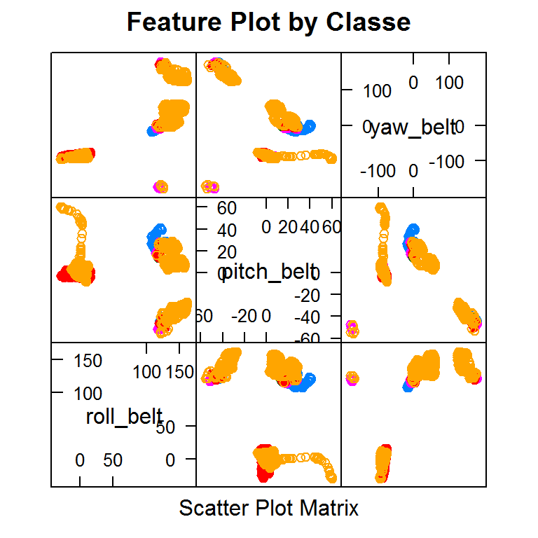

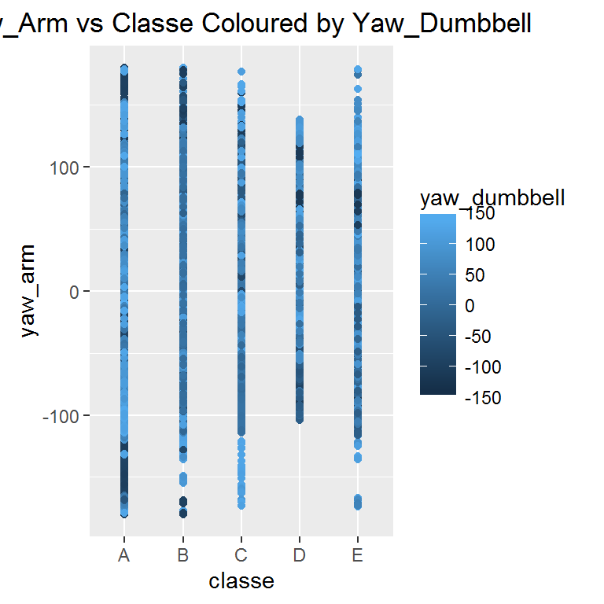

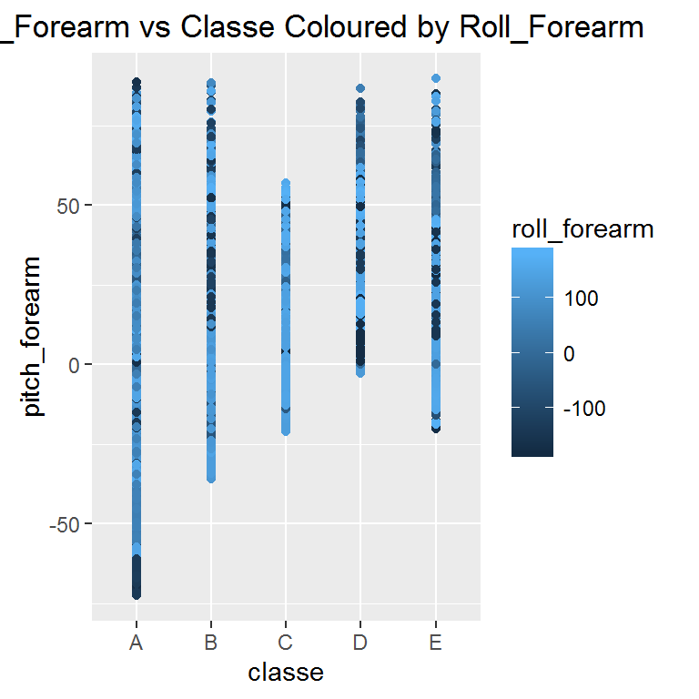

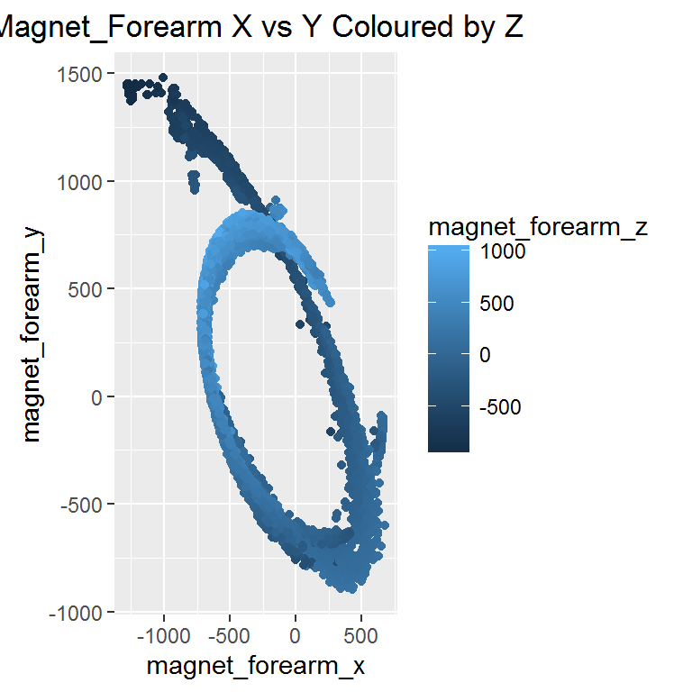

There isn’t any clear indication of a pattern given random sets of variables in the plots. However, given that it is a classification problem–and there are 53 remaining variables to work with–the machine learning algorithms should be able to build patterns not readily evident on 2 dimensional plots.

## Building Models

I chose to build two opposing models, in order to compare methods and their effectiveness/accuracy on the number of variables, and continuous range of values associated with those variables.

The **Random Forest** model balances the highest accuracy with the tendency for overfitting. With no easily noticeable pattern in the training data, Random Forest runs the risk of creating too many subtrees. The **Boosting** model may potentially be less accurate than the Random Forest, but it uses averages of error rates (from weaker predictions) to build a stronger, generalized fit.

If the models respond with substantially different results when predicting the Testing data, then they may need to be combined to build a better model, or re-evaluated in the amount of data they work with.

### Random Forest

```r
mod1 <- train(classe ~ ., method="rf", data=trainSub, trControl = trainControl(method="cv"), number=5)
print(mod1)
```

```
## Random Forest
##
## 11776 samples
##    52 predictor
##     5 classes: 'A', 'B', 'C', 'D', 'E'
##
## No pre-processing
## Resampling: Cross-Validated (10 fold)
## Summary of sample sizes: 10599, 10599, 10598, 10598, 10599, 10598, ...
## Resampling results across tuning parameters:
##
##   mtry  Accuracy   Kappa
##    2    0.9898106  0.9871092
##   27    0.9893864  0.9865735
##   52    0.9854807  0.9816313
##
## Accuracy was used to select the optimal model using  the largest value.
## The final value used for the model was mtry = 2.
```

```r
pred1 <- predict(mod1, testing)
```

### Generalized Boosted Regression

```r
mod2 <- train(classe ~ ., method="gbm", data=trainSub, verbose=FALSE)
print(mod2)
```

```
## Stochastic Gradient Boosting
##
## 11776 samples
##    52 predictor
##     5 classes: 'A', 'B', 'C', 'D', 'E'
##
## No pre-processing
## Resampling: Bootstrapped (25 reps)
## Summary of sample sizes: 11776, 11776, 11776, 11776, 11776, 11776, ...
## Resampling results across tuning parameters:
##
##   interaction.depth  n.trees  Accuracy   Kappa
##   1                   50      0.7479867  0.6807220
##   1                  100      0.8143928  0.7651898
##   1                  150      0.8497457  0.8099218
##   2                   50      0.8523583  0.8129931
##   2                  100      0.9023912  0.8764488
##   2                  150      0.9262634  0.9066729
##   3                   50      0.8926746  0.8641129
##   3                  100      0.9351797  0.9179593
##   3                  150      0.9548368  0.9428500
##
## Tuning parameter 'shrinkage' was held constant at a value of 0.1
##
## Tuning parameter 'n.minobsinnode' was held constant at a value of 10
## Accuracy was used to select the optimal model using  the largest value.
## The final values used for the model were n.trees = 150,
##  interaction.depth = 3, shrinkage = 0.1 and n.minobsinnode = 10.
```

```r
pred2 <- predict(mod2, testing)
```

## Error Rates

To take a look at the correct predictions in the Testing data, I built a table using each of the predicted results.

```r
# Random Forest Predictions
table(pred1, testing$classe)
```

```
##
## pred1    A    B    C    D    E
##     A 2228    9    0    0    0
##     B    3 1501   12    0    0
##     C    0    8 1356   25    0
##     D    0    0    0 1259    0
##     E    1    0    0    2 1442
```

```r
# Boosting Predictions
table(pred2, testing$classe)
```

```
##
## pred2    A    B    C    D    E
##     A 2207   46    0    4    1
##     B   20 1425   49    7   31
##     C    3   43 1300   44   18
##     D    2    3   17 1221   28
##     E    0    1    2   10 1364
```

### In Sample Error Rates

Since this is a classification problem, and not one with continuous values (which would use the Mean Squared Error function), the Misclassification Errors are calculated as follows:

```r
pred1Err <- 1 - ((sum(pred1 == testing$classe))/(dim(testing))[1])
pred2Err <- 1 - ((sum(pred2 == testing$classe))/(dim(testing))[1])

pred1Err
```

```
## [1] 0.007647209
```

```r
pred2Err
```

```
## [1] 0.04193219
```

Given that the Valdation set is the Out of Sample Error target, the correctness of the Testing data predictions is the In Sample Error. As can be noted, both are very close in their correctness and also close to the value of perfect purity (0).

This suggests that the cross-validation as part of the predictor methods was substantial enough that re-evaluating the models is unnecessary.

### Out of Sample Error

Since it is known that there are 20 observations in the Validation data, the expected errors are as follows:

```r
# Expected Random Forest Error
20 * pred1Err
```

```
## [1] 0.1529442
```

```r
# Expected Boosting Error
20 * pred2Err
```

```
## [1] 0.8386439
```

## Prediction

Given that the Random Forest model produces slightly more accurate results than the Boosting model, I used that model to predict the validation cases.

```r
predict(mod1, dataTest)
```

```
##  [1] B A B A A E D B A A B C B A E E A B B B
## Levels: A B C D E
```